# week_11_review_lm_nonlinear

## CMPINF 2100 Week 11

### REVIEW: Linear model assumptions - linear models allow for NONLINEAR relationships

## Import Modules

```python
import numpy as np
import pandas as pd
import matplotlib.pyplot as plt

import seaborn as sns
```

## Problem statement

We prev reviewed the major assumptions of a linear model, but theres 1 more we need to cover!!

Linear models do NOT mean straight lines!

The MEAN OUTPUT or TREND can be related to a **FEATURE** derived from an input. That FEATURE can be the result of a NON-LINEAR TRANSFORMATION of the input!!!

The TREND is therefore NON-LINEARLY related to the INPUT!!

What matters is that the TREND is LINEARLY RELATED to the UNKNOWN INTERCEPT AND SLOPE of the linear model!!

Lets see that by working with the sine-wave from last week.

$$\mu = \beta_0 + \beta_1 \times sin(x) $$

## Visualize behavior

Define a set of TRUE regression coefficients to generate the data.

```python
my_intercept = 0.25
my_slope = -2.25
```

```python
df_viz = pd.DataFrame({"x":np.linspace(-3.14159, 3.14159, num=101)})
```

```python
df_viz["trend"] = my_intercept + my_slope * np.sin(df_viz.x)
```

Visualize the trend given the input.

```python
sns.set_style("whitegrid")
```

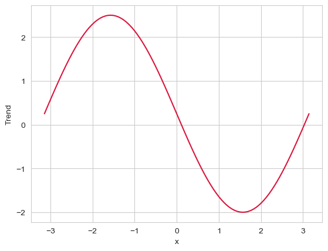

```python
fig, ax = plt.subplots()

ax.plot(df_viz.x, df_viz.trend, color="crimson", linewidth=1.5)

ax.set_xlabel("x")
ax.set_ylabel("Trend")

plt.show()
```

Remember...there is a linear relationship between the TREND and the NON-LINEAR FEATURE!!

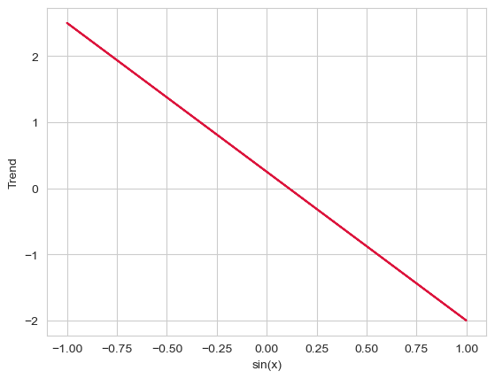

```python
fig, ax = plt.subplots()

ax.plot(np.sin(df_viz.x), df_viz.trend, color="crimson", linewidth=1.5)

ax.set_xlabel("sin(x)")
ax.set_ylabel("Trend")

plt.show()
```

We are creating the linear model between the TREND and some NON-LINEAR FEATURE (ex: sin(x))

Specify the LEVEL OF VARIATION or UNCERTAINTY of a single measurement around the trend.

Last week, we used a SIGMA of 0.1 but this week lets increase it to 0.33.

```python
my_sigma = 0.33
```

The output or a SINGLE MEASUREMENT of the OUTPUT is NORMALLY distributed AROUND the mean.

Lets summarize the variation using the 68% and 95% uncertainty intervals.

```python
df_viz["obs_lwr_68"] = df_viz.trend - my_sigma
df_viz["obs_upr_68"] = df_viz.trend + my_sigma
```

```python
df_viz["obs_lwr_95"] = df_viz.trend - 2 * my_sigma
df_viz["obs_upr_95"] = df_viz.trend + 2 * my_sigma
```

```python
df_viz
```

|  | x | trend | obs_lwr_68 | obs_upr_68 | obs_lwr_95 | obs_upr_95 |
| --- | --- | --- | --- | --- | --- | --- |
| 0 | -3.141590 | 0.250006 | -0.079994 | 0.580006 | -0.409994 | 0.910006 |
| 1 | -3.078758 | 0.391285 | 0.061285 | 0.721285 | -0.268715 | 1.051285 |
| 2 | -3.015926 | 0.532005 | 0.202005 | 0.862005 | -0.127995 | 1.192005 |
| 3 | -2.953095 | 0.671613 | 0.341613 | 1.001613 | 0.011613 | 1.331613 |
| 4 | -2.890263 | 0.809558 | 0.479558 | 1.139558 | 0.149558 | 1.469558 |
| ... | ... | ... | ... | ... | ... | ... |
| 96 | 2.890263 | -0.309558 | -0.639558 | 0.020442 | -0.969558 | 0.350442 |
| 97 | 2.953095 | -0.171613 | -0.501613 | 0.158387 | -0.831613 | 0.488387 |
| 98 | 3.015926 | -0.032005 | -0.362005 | 0.297995 | -0.692005 | 0.627995 |
| 99 | 3.078758 | 0.108715 | -0.221285 | 0.438715 | -0.551285 | 0.768715 |
| 100 | 3.141590 | 0.249994 | -0.080006 | 0.579994 | -0.410006 | 0.909994 |

101 rows × 6 columns

Lets visualize the uncertainty of the measurement using ribbons.

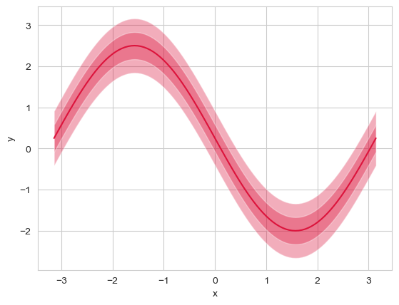

```python
fig, ax = plt.subplots()

ax.plot(df_viz.x, df_viz.trend, color="crimson", linewidth=1.5)
# variation around the trend - showing 2 intervals
# 2 sigma interval
ax.fill_between(df_viz.x, df_viz.obs_lwr_95, df_viz.obs_upr_95, facecolor="crimson", alpha=0.35)

# 1 sigma interval
ax.fill_between(df_viz.x, df_viz.obs_lwr_68, df_viz.obs_upr_68, facecolor="crimson", alpha=0.35)

# set labels
ax.set_xlabel("x")
ax.set_ylabel("y")

# show the plot
plt.show()
```

## Generate the random output data

Generate a small number of random output measurements at given input locations.

We will use more input locations than the linear relationship example.

```python
df = pd.DataFrame({"x": np.linspace(-3, 3, num=15)})
```

```python
df.head()
```

|  | x |
| --- | --- |
| 0 | -3.000000 |
| 1 | -2.571429 |
| 2 | -2.142857 |
| 3 | -1.714286 |
| 4 | -1.285714 |

```python
df["trend"] = my_intercept + my_slope * np.sin(df.x)
```

Initialize the random number generator and then call the appropriate generator function.

```python
rg = np.random.default_rng(2100)
```

```python
df["y"] = rg.normal(loc=df.trend,
                    scale=my_sigma,
                    size=df.shape[0])
```

```python
df.head()
```

|  | x | trend | y |
| --- | --- | --- | --- |
| 0 | -3.000000 | 0.567520 | 0.905523 |
| 1 | -2.571429 | 1.464483 | 0.892371 |
| 2 | -2.142857 | 2.141771 | 2.112304 |
| 3 | -1.714286 | 2.476877 | 2.115940 |
| 4 | -1.285714 | 2.409187 | 2.515115 |

Visualize the randomly generated outputs around the trend.

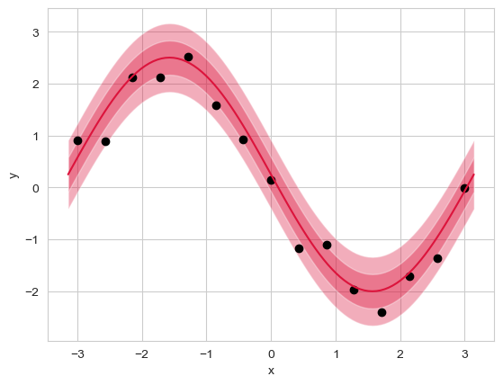

```python
fig, ax = plt.subplots()

ax.plot(df_viz.x, df_viz.trend, color="crimson", linewidth=1.5)
# variation around the trend - showing 2 intervals
# 2 sigma interval
ax.fill_between(df_viz.x, df_viz.obs_lwr_95, df_viz.obs_upr_95, facecolor="crimson", alpha=0.35)

# 1 sigma interval
ax.fill_between(df_viz.x, df_viz.obs_lwr_68, df_viz.obs_upr_68, facecolor="crimson", alpha=0.35)

# lets include the randomly generate small data
ax.scatter(df.x, df.y, color="k")

# set labels
ax.set_xlabel("x")
ax.set_ylabel("y")

# show the plot
plt.show()
```

We are trying to model the trend, which changes based on the INPUTS.

Any variation around that trend is uncontrollable, unexplainable, or purely random. Thats what sigma represents of our Gaussian.

```python
df.y.std()
```

```
1.6288504605641019
```

Lets save the randomly generates data, and as with the previous example, let's include the true coefficients and sigma that made the data.

```python
df["true_intercept"] = my_intercept
```

```python
df["true_slope"] = my_slope
```

```python
df["true_sigma"] = my_sigma
```

```python
df.head()
```

|  | x | trend | y | true_intercept | true_slope | true_sigma |
| --- | --- | --- | --- | --- | --- | --- |
| 0 | -3.000000 | 0.567520 | 0.905523 | 0.25 | -2.25 | 0.33 |
| 1 | -2.571429 | 1.464483 | 0.892371 | 0.25 | -2.25 | 0.33 |
| 2 | -2.142857 | 2.141771 | 2.112304 | 0.25 | -2.25 | 0.33 |
| 3 | -1.714286 | 2.476877 | 2.115940 | 0.25 | -2.25 | 0.33 |
| 4 | -1.285714 | 2.409187 | 2.515115 | 0.25 | -2.25 | 0.33 |

```python
df.to_csv("week_11_nonlinear_data.csv", index=False)
```